# Hate Crimes Before and After the 2016 Election

Yuren Pang, Kaia Lund, Kayla Hostetler

5/3/2018

```r
library(dplyr)
library(ggplot2)
library(gridExtra)
```

In the fivethirtyeight $\href{https://fivethirtyeight.com/features/higher-rates-of-hate-crimes-are-tied-to-income-inequality/}{\text{article}}$, Maimuna Majumber concluded that hate crimes are tied to income inequality by analyzing the correlations between hate crimes rate and nine different socioeconomic factors. We were motivated by exploring the statistical techniques to identify the social problems and make social impacts. In this Math 155 miniproject, we conducted a confirmatory research on Majumber’s conclusion, specifically how does the income inquality (measured by the Gini index) impact the average number of hate incidents (per 100,000 people)? In addition, we were very interested in the role of Donald Trump’s election in changing the hate crime incidents. Therefore, we pose another two research questions: how does the percent of population voted for Trump affect the average number of hate crimes in general? Or, do the two factors play any roles in influencing hate crimes at all?

## Choosing Our Dataset

We based our project off of the fivethirtyeight data. The dataset contains nine potential socioeconomic factors which potentially impact the pre and post election hate crime rates in 51 states. The main variables that we used are: 1) Gini index which measures the income inequality in each state (`gini_index`), 2) the percent of population voted for Trump in each state (`share_vote_trump`), 3) the pre-election average number of hate crimes (per 100,000 people) in one year from 2010 to 2015 (`avg_hatecrimes_per_100k_fbi`), 4) the post-election number of hate crimes ((per 100,000 people) in ten days after the 2016 election (`hate_crimes_per_100k_splc`).

```r
library(fivethirtyeight)
data(hate_crimes)
head(hate_crimes)
```

```
## # A tibble: 6 x 12
##   state     median_house_inc share_unemp_seas share_pop_metro share_pop_hs
##   <chr>                <int>            <dbl>           <dbl>        <dbl>
## 1 Alabama              42278           0.0600           0.640        0.821
## 2 Alaska               67629           0.0640           0.630        0.914
## 3 Arizona              49254           0.0630           0.900        0.842
## 4 Arkansas             44922           0.0520           0.690        0.824
## 5 Californ…            60487           0.0590           0.970        0.806
## 6 Colorado             60940           0.0400           0.800        0.893
## # ... with 7 more variables: share_non_citizen <dbl>,
## #   share_white_poverty <dbl>, gini_index <dbl>, share_non_white <dbl>,
## #   share_vote_trump <dbl>, hate_crimes_per_100k_splc <dbl>,
## #   avg_hatecrimes_per_100k_fbi <dbl>
```

## Majumber’s Analysis

First of all, we would like to test Majumber’s conclusion. Before the testing, we started off by visualizing the two important response variables: the pre-election and post-election number of hate crimes. Note that the pre-election measures the average number in one year from 2010 to 2015, whereas the post-election measures the incidents which happened in ten days.

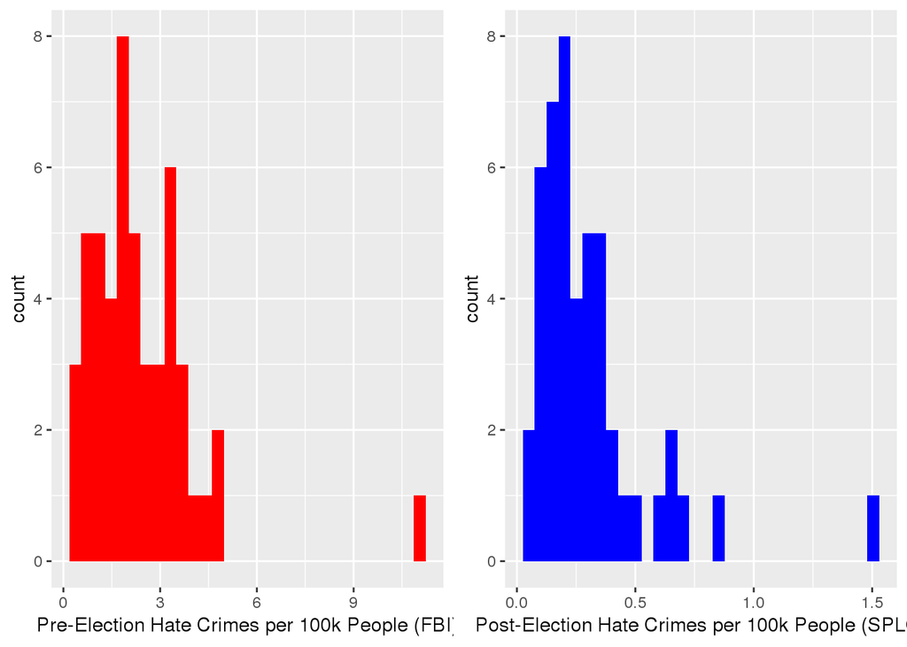

```r
#The pre-election average number of hate crimes in a year
pre.his <- ggplot(hate_crimes, aes(x=avg_hatecrimes_per_100k_fbi))+
  geom_histogram(fill = "red") +
  labs(x="Pre-Election Hate Crimes per 100k People (FBI)")

#The post-election number of hate crimes in ten days
post.his <- ggplot(hate_crimes, aes(x=hate_crimes_per_100k_splc))+
  geom_histogram(fill = "blue") +
  labs(x="Post-Election Hate Crimes per 100k People (SPLC)")

grid.arrange(pre.his, post.his, widths = c(1,1), nrow=1)
```

After gaining some insights, we followed Majumber’s analysis and explored the relationship between these data and the income inequality (Gini index).

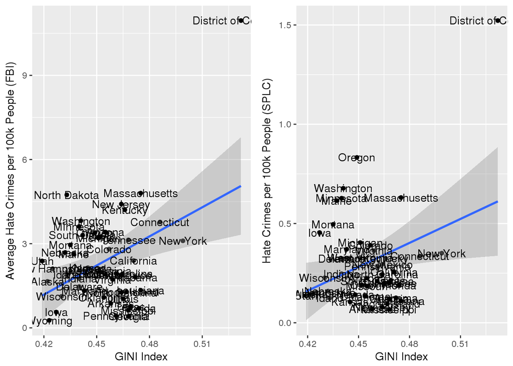

```r
#pre-election relationship between gini_index and hate crimes data from the fbi
pre.vis <- ggplot(hate_crimes, aes(x=gini_index, y=avg_hatecrimes_per_100k_fbi)) +
  geom_point() +
  geom_smooth(method="lm") +
  geom_text(aes(label=state)) +
  labs(x="GINI Index", y="Average Hate Crimes per 100k People (FBI)")

#post-election relationship between gini_index and hate crimes data from the splc
post.vis <- ggplot(hate_crimes, aes(x=gini_index, y=hate_crimes_per_100k_splc)) +
  geom_point() +
  geom_smooth(method="lm") +
  geom_text(aes(label=state)) +
  labs(x="GINI Index", y="Hate Crimes per 100k People (SPLC)")

grid.arrange(pre.vis, post.vis, nrow = 1)
```

## Removing the Outliers

What stood out was the fact that there is one outlier with extremely high numbers of hate crimes in all four visualizations. It turned out that the outlier is District of Columbia. Then, we removed the outlier. Note that the FBI data do not have information in Hawaii whereas the SPLC data do not have numbers in Hawaii, North Dakota, South Dakota, and Wyoming. That’s why we created two new dataset.

```r
#Outlier removed of the pre-election hate crimes variable
hate_crimes1 <- hate_crimes %>%
  filter(avg_hatecrimes_per_100k_fbi < 9)

#Outlier removed in the post-election hate crimes variable
hate_crimes2 <- hate_crimes %>%
  filter(hate_crimes_per_100k_splc < 1.5)
```

Then, we constructed new multivariate linear regressions and explored the relationships between the same variables in Majumber’s analysis.

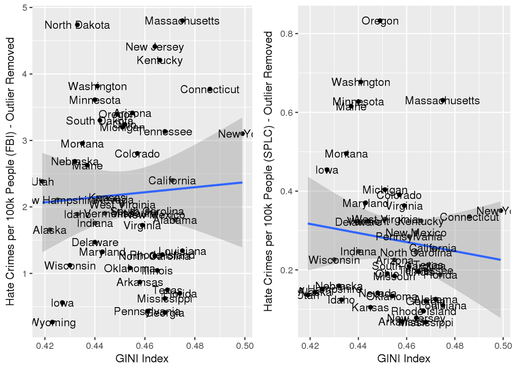

```r
#Pre-election
rem.out.pre <- ggplot(hate_crimes1, aes(x=gini_index, y=avg_hatecrimes_per_100k_fbi)) +
  geom_point() +
  geom_smooth(method="lm") + geom_text(aes(label=state)) +
  labs(x="GINI Index", y="Hate Crimes per 100k People (FBI) - Outlier Removed")

#Post-election
rem.out.post <- ggplot(hate_crimes2, aes(x=gini_index, y=hate_crimes_per_100k_splc)) +
  geom_point()+
  geom_smooth(method="lm") +
  geom_text(aes(label=state)) +
  labs(x="GINI Index", y="Hate Crimes per 100k People (SPLC) - Outlier Removed")

grid.arrange(rem.out.pre, rem.out.post, nrow = 1)
```

```r
#The big p-value indicates a weak significance.
model_fbi <- lm(avg_hatecrimes_per_100k_fbi ~ gini_index, hate_crimes1)
summary(model_fbi)
```

```
##
## Call:
## lm(formula = avg_hatecrimes_per_100k_fbi ~ gini_index, data = hate_crimes1)
##
## Residuals:
##     Min      1Q  Median      3Q     Max
## -1.8385 -0.9642 -0.2271  0.8855  2.6227
##
## Coefficients:
##             Estimate Std. Error t value Pr(>|t|)
## (Intercept)   0.4837     4.4367   0.109    0.914
## gini_index    3.7755     9.7954   0.385    0.702
##
## Residual standard error: 1.208 on 47 degrees of freedom
## Multiple R-squared:  0.003151,   Adjusted R-squared:  -0.01806
## F-statistic: 0.1486 on 1 and 47 DF,  p-value: 0.7017
```

```r
#The big p-value indicates a weak significance.
model_splc <- lm(hate_crimes_per_100k_splc ~ gini_index, hate_crimes2)
summary(model_splc)
```

```
##
## Call:
## lm(formula = hate_crimes_per_100k_splc ~ gini_index, data = hate_crimes2)
##
## Residuals:
##      Min       1Q   Median       3Q      Max
## -0.20381 -0.14320 -0.04881  0.08871  0.54960
##
## Coefficients:
##             Estimate Std. Error t value Pr(>|t|)
## (Intercept)   0.8009     0.6917   1.158    0.253
## gini_index   -1.1528     1.5227  -0.757    0.453
##
## Residual standard error: 0.1786 on 44 degrees of freedom
## Multiple R-squared:  0.01286,    Adjusted R-squared:  -0.009577
## F-statistic: 0.5731 on 1 and 44 DF,  p-value: 0.4531
```

The pre-election data (FBI, hate crimes per 100k people) only has a slight positive relationship with the gini index and there is a slight negative relationship between the post election data (SPLC, hate crimes per 100k people) and the gini index. As a matter of fact, two models with $p_1 = 0.702$ and $p_2 = 0.453$ indicate that we cannot reject the null hypothesis that the coefficient $b=0$ if we would like to be 95% confident. (The alternative hypothesis would be $b \neq 0$.) As a result, we found significant flaws of the analysis in the fivethirtyeight article by removing the outlier of District of Columbia. It was because of the outlier of the District of Columbia that Majumber found a strong positive relationship between hate crimes rate and the Gini index.

## Create a New Variable: `crime_diff`

To further test that our rejection of the Fivethirtyeight article, we create a new variable: `crime_diff` which measures the change of daily number of hate crimes in each state after the 2016 election. Note that due to the lack of data in the post-election hate crimes variable, we can only use 46 states without District of Columbia (the outlier), Hawaii, North Dakota, South Dakota, and Wyoming.

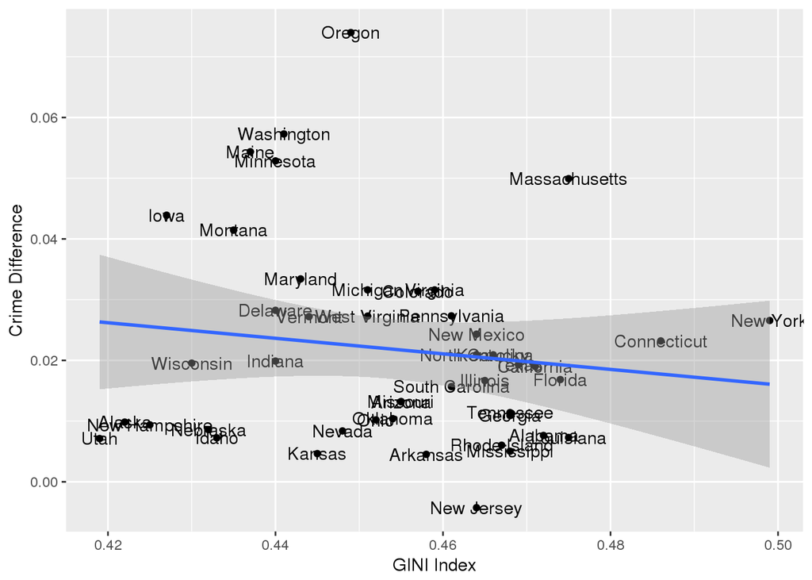

```r
#Create a new variable to measure the daily hate crime number change before and after the election except five states
hate_crimes_new <- hate_crimes2 %>%
  mutate(crime_diff = hate_crimes_per_100k_splc/10 - avg_hatecrimes_per_100k_fbi/365)

ggplot(hate_crimes_new, aes(x=gini_index, y=crime_diff)) +
  geom_point()+
  geom_text(aes(label=state))+
  geom_smooth(method="lm")+
  labs(x="GINI Index", y="Crime Difference")
```

```r
#This model indicates that there is no relationship between the change of hate crimes and income inequality.
model_diff <- lm(crime_diff ~ gini_index, hate_crimes_new)
summary(model_diff)
```

```
##
## Call:
## lm(formula = crime_diff ~ gini_index, data = hate_crimes_new)
##
## Residuals:
##       Min        1Q    Median        3Q       Max
## -0.024823 -0.011906 -0.003097  0.008632  0.051500
##
## Coefficients:
##             Estimate Std. Error t value Pr(>|t|)
## (Intercept)  0.08000    0.06416   1.247    0.219
## gini_index  -0.12810    0.14125  -0.907    0.369
##
## Residual standard error: 0.01656 on 44 degrees of freedom
## Multiple R-squared:  0.01835,    Adjusted R-squared:  -0.00396
## F-statistic: 0.8225 on 1 and 44 DF,  p-value: 0.3694
```

Still, 0 would fall in the 95% confidence interval in this model. The measure of hate crime changes after election did not support the fivethirtyeight’s conclusion, either. Therefore, we can reject the conclusion on the Fivethirtyeight article after the outlier is removed based on the dataset we have.

## Trump and Hate Crimes?

It is $\href{https://www.washingtonpost.com/news/post-nation/wp/2018/03/23/hate-crimes-rose-the-day-after-trump-was-elected-fbi-data-show/?noredirect=on&utm_term=.ddfa67f4c565}{\text{reported}}$ that hate crimes rose the days after Trump was elected. We were very interested the role of Trump’s election in 2016 in the hate crimes dynamics and would like to explore the role with the aid of the data in the `hate_crimes_new` based on the given dataset `hate_crimes`. Because the SPLC did not have data in North Dakota, South Dakota, Wyoming, we decided to use the daily crime change after the election `crime_diff` as the response variable. We explored the following relationship between the share of people voted for Trump and the increase (or decrease) of hate crimes in each state.

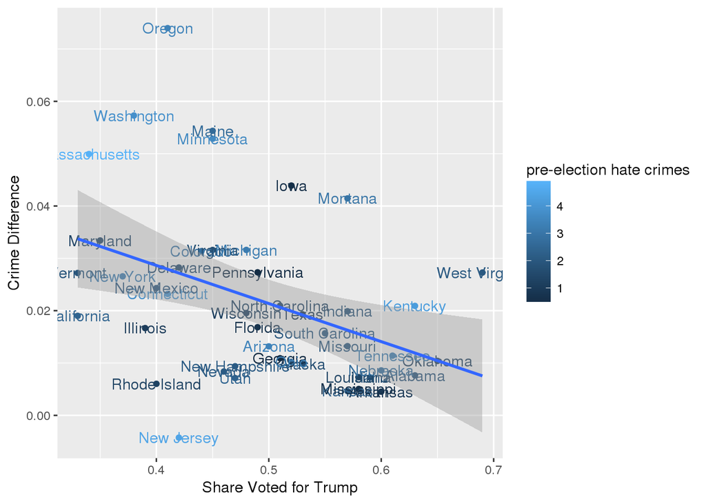

```r
ggplot(hate_crimes_new, aes(x=share_vote_trump, y=crime_diff, col = avg_hatecrimes_per_100k_fbi)) +
  geom_point()+
  geom_text(aes(label=state))+
  geom_smooth(method="lm")+
  labs(x="Share Voted for Trump", y="Crime Difference", col = "pre-election hate crimes")
```

```r
#this model indicates that there is a strong significance between the share_vote_trump and the increase of hate crimes in a state
model_diff <- lm(crime_diff ~ share_vote_trump + avg_hatecrimes_per_100k_fbi, hate_crimes_new)
summary(model_diff)
```

```
##
## Call:
## lm(formula = crime_diff ~ share_vote_trump + avg_hatecrimes_per_100k_fbi,
##     data = hate_crimes_new)
##
## Residuals:
##       Min        1Q    Median        3Q       Max
## -0.038712 -0.007896 -0.002697  0.005089  0.042514
##
## Coefficients:
##                              Estimate Std. Error t value Pr(>|t|)
## (Intercept)                  0.045137   0.014113   3.198  0.00259 **
## share_vote_trump            -0.062674   0.024850  -2.522  0.01545 *
## avg_hatecrimes_per_100k_fbi  0.003543   0.002030   1.746  0.08798 .
## ---
## Signif. codes:  0 '***' 0.001 '**' 0.01 '*' 0.05 '.' 0.1 ' ' 1
##
## Residual standard error: 0.01494 on 43 degrees of freedom
## Multiple R-squared:  0.2198, Adjusted R-squared:  0.1835
## F-statistic: 6.056 on 2 and 43 DF,  p-value: 0.004815
```

Intuitively we would think that the more people voted for Trump, the number of hate crimes would increase more. However, the above model illustrates that there is strong negative relationship between the two variables. It indicates that the redder states tend to have less increase in the hate crimes. This is rather surprising. Although we found this significant relationship, we could not ascertain the reason behind this discovery. Initially, we thought it could result from the fact that the redder states had higher numbers of hate crimes before the election so there could not have been much room for increase. Therefore, We assigned different colors to each state based on the hate crime numbers before (darker color means lower number of hate crimes). However, we found that most redder states on the bottom right corner such as Oklahoma and Alabama had lower average hate crimes compared with blue states such as Massachusetts, Washington, and Oregon which had very high post-election increase of hate crimes.

Hence, we need research on this finding with more comprehensive dataset in the future.

## Make a Prediction of the Hate Crime Changes

In the end, we would like to show the practicality of our project. We would like to predict the potential changes of hate crimes given the pre-election hate crimes data. We conduct a model in which the pre-election hate crimes is the predictor and the change of hate crimes is the response variable. We created our null hypothesis that there is no correlation between pre-election hate crimes and the post-election change of hate crimes $c = 0$. Our alternative hypothesis is that the higher the number of hate crimes each state has, the more hate crimes they would encounter after the election. $c > 0$

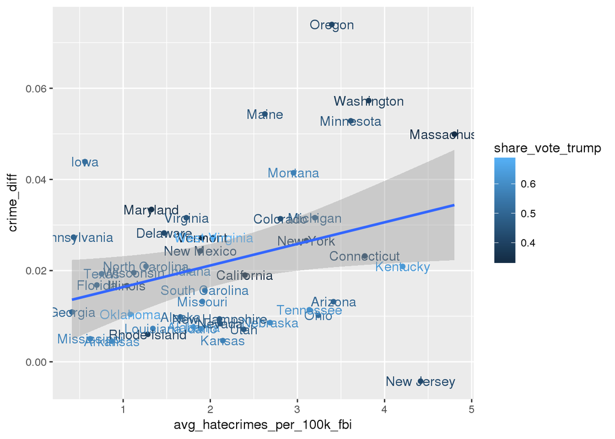

```r
ggplot(hate_crimes_new, aes(x=avg_hatecrimes_per_100k_fbi, y=crime_diff, col=share_vote_trump)) +
  geom_point()+
  geom_text(aes(label=state))+
  geom_smooth(method="lm")
```

```r
model_predictor <- lm(crime_diff ~ avg_hatecrimes_per_100k_fbi, hate_crimes_new)
summary(model_predictor)
```

```
##
## Call:
## lm(formula = crime_diff ~ avg_hatecrimes_per_100k_fbi, data = hate_crimes_new)
##
## Residuals:
##       Min        1Q    Median        3Q       Max
## -0.036810 -0.011589 -0.001392  0.006509  0.046255
##
## Coefficients:
##                             Estimate Std. Error t value Pr(>|t|)
## (Intercept)                 0.011657   0.005073   2.298   0.0264 *
## avg_hatecrimes_per_100k_fbi 0.004734   0.002091   2.264   0.0285 *
## ---
## Signif. codes:  0 '***' 0.001 '**' 0.01 '*' 0.05 '.' 0.1 ' ' 1
##
## Residual standard error: 0.01582 on 44 degrees of freedom
## Multiple R-squared:  0.1044, Adjusted R-squared:  0.08402
## F-statistic: 5.127 on 1 and 44 DF,  p-value: 0.02853
```

We are more than 95% confident that there is a positive relationship between hate crime changes and the average numbers of hate crimes before election.

## The Conclusion and Concerns

In this report, we found that the there is no significant relationship between hate crimes and income inequality after we analyzed the dataset without the outlier of Washington DC. We also found that there is a significant negative relationship between the hate crime changes and the share of people who voted for Trump. We also made the inference in the end that the more hate crimes you have, the even more increase hate crimes the state will encounter.